# Introduction

## Project charter

Drive sales and brand awareness by using visitors’ interactions with the bank’s budgeting app to inform targeting, content generation, and app development to increase engagement, retention, and ultimately sales (loans, credit cards, checking/savings accounts).

## Current Investigation

**Hypothesis:** There are distinct types of first time interactions that users have with the app that result in differentiated long-term user behavior (e.g. different expected lifetimes, higher rate of account enrollments).

Previously, we identified that the highest rates of churn tend to occur right after the first visit to the app. Therefore, understanding the first visit provides the opportunity for identifying factors that lead to churn and identifying potential solutions. By identifying patterns in what first visits to the app look like, the client will potentially be able to:

- Assess which first visits result in the largest rate of churn to help inform app developers what should be addressed to retain potential churners most effectively during that first visit.
- Get signals as to users' motivations for using the app, which could help to identify needs that are or are not met by the app.
- Understand the types of visits that lead to *higher* rates of engagement, retention, and sales and assess the commonalities across the users who have these first visit types to shed light on what types of users are being well served by the app. This information could be used to inform targeting of marketing to bring in users more likely to get value from the app and therefore, remain engaged and potentially open an account.

## Guiding Questions

1. What do users’ first visits to the apps look like? (This is a proxy for intention in downloading the app).
2. How do these visit types relate to:
   - Likelihood of returning to the app?
   - Lifetime of app usage?

# Summary

## Key decisions

- The number of clusters was chosen as five in order to strike a balance between the silhouette score, inertia, and utility in a business setting.

## Key Findings

1. A segment of users come in and quickly explore all of the different app features and then leave. These users are the least likely t"o return - they saw everything and were not interested.
2. Those who explore the app for an extended period of time during their first visit **and** make it back for a second visit show that they found value in the app and demonstrate longer lifetimes than all other segments.
3. Those who set up a budget are most likely to return a second time.

## Next steps

- Assess demographic differences between clusters.
- Dive deeper into the characteristics of users in the extended exploring cluster and assess whether specific pages or features lead to users return.

```python
# Required Python packages and configurations for performing analysis
%matplotlib inline
%config InlineBackend.figure_format='retina'

import matplotlib as mpl
from matplotlib import pyplot as plt
from matplotlib.pyplot import GridSpec
import seaborn as sns
import numpy as np
import pandas as pd
import os, sys
import warnings
import datetime
from pyhive import hive

# SVDS imports
import svdsvis as sv

from sklearn.decomposition import PCA
from sklearn.preprocessing import StandardScaler
from sklearn.cluster import AgglomerativeClustering, KMeans
from sklearn import metrics

sns.set_context("poster", font_scale=1.3)
```

# Data Input

In this notebook, we use the features generated previously (see analytical documentation here that describe the first visits of users of the app. The details required to reproduce these featurse are as follows:

- **Raw file/table name:** `database.geature_table`
- **Table generation date:** `2017-05-02`
- **Description of data:** Features generate to describe users' first visits to the app, as developed in the prior notebook found here.
- **Date range covered by data:** `2016-11-01` to `2017-05-02`
- **Included population:** All visitors to application assosciated with a known value of `domain`, as of time of query.
- **Associated query file:** `src/sql/generate_features.sql` ([view on GitHub](https://github.com/silicon-valley-data-science/product-analytics/blob/ben-asset/hubspot-clickstream-segmentation/src_python/data/collection.py))

```
SELECT
    length_of_path,
    number_distinct_pages,
    avg_time_between_pages,
    duration,
    number_categories,
    fraction_welcome,
    fraction_budget,
    fraction_advice,
    fraction_help,
    fraction_settings
FROM
    database.feature_table;
```

```python
query = """
SELECT
    length_of_path,
    number_distinct_pages,
    avg_time_between_pages,
    duration,
    number_categories,
    fraction_welcome,
    fraction_budget,
    fraction_advice,
    fraction_help,
    fraction_settings
FROM
    database.feature_table;
"""
```

The above query was run and the resulting data ingested into the notebook as a pandas dataframe at the date and time printed.

```python
cursor = hive.connect('host.name').cursor()
cursor.execute()
df_features = cursor.fetchall()
print(datetime.datetime.now())
```

```
2017-05-03 11:32:45
```

# Explore features

```python
# Set up plotting configuration
feature_labels = ['Length of path',
                  'Number of distinct pages'
                  'Average time between actions',
                  'Duration of visit',
                  'Number of categories visited',
                  'Fraction of pages in welcome and onboarding',
                  'Fraction of pages in budget tool',
                  'Fraction of pages in advice category',
                  'Fraction of pages in help category',
                  'Fraction of pages in settings category']

column_labels = dict(zip(df_features.columns, feature_labels))
feat_plot = sv.SVDSvisDF(df_features,  column_labels=column_labels)
```

The dataset used in the steps below has the following format:

```python
print(df_features.dtypes)
```

```
length_of_path            float64
number_distinct_pages     float64
avg_time_between_pages    float64
duration                  float64
number_categories         float64
fraction_welcome          float64
fraction_budget           float64
fraction_advice           float64
fraction_help             float64
fraction_settings         float64
dtype: object
```

Each row represents a distinct visit to the app, and each column represents a feature of that visit. Visits are defined as groups of actions taken by an individual in a single session. Sessionization and entity resolution are determined by the backend instrumetation, and are assumed to be fixed for the purposes of this analysis.

## Behavioral features

Some features describe the behavior of the visitor (e.g. `avg_time_between_actions`, `duration_of_visit`, ...).

```python
# define the behavioral features
behavioral_features = ['length_of_path',
                      'number_categories',
                      'avg_time_between_pages',
                      'duration',]
# show them
df_features[behavioral_features].head()
```

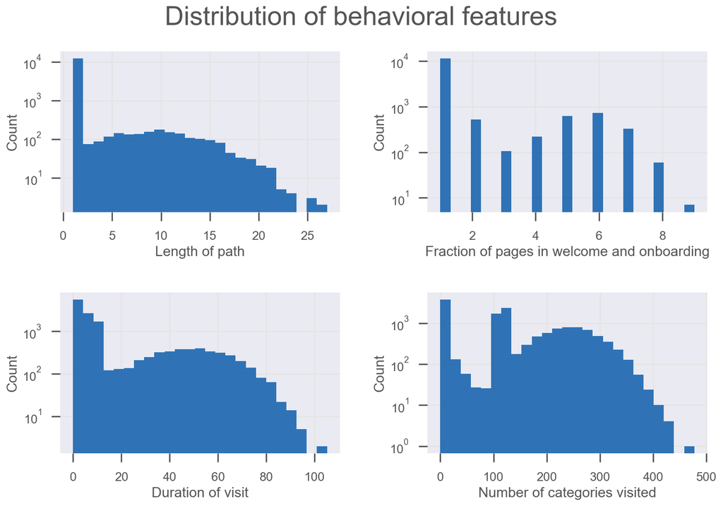

```python
fig, ax = feat_plot.subplots(behavioral_features,
                             kind='hist', bins=25,log=True,
                             main_title='Distribution of behavioral features')
```

## Content-based features

Other features describe how much of their first visit was within each category.

```python
# define the content features
content_features = ['fraction_welcome',
                    'fraction_budget',
                    'fraction_advice',
                    'fraction_help',
                    'fraction_settings']
# show them
df_features[content_features].head()
```

### Percent of users visiting each category

Everyone reaches the welcome screen that opens the app. From there, page visits vary across the users.

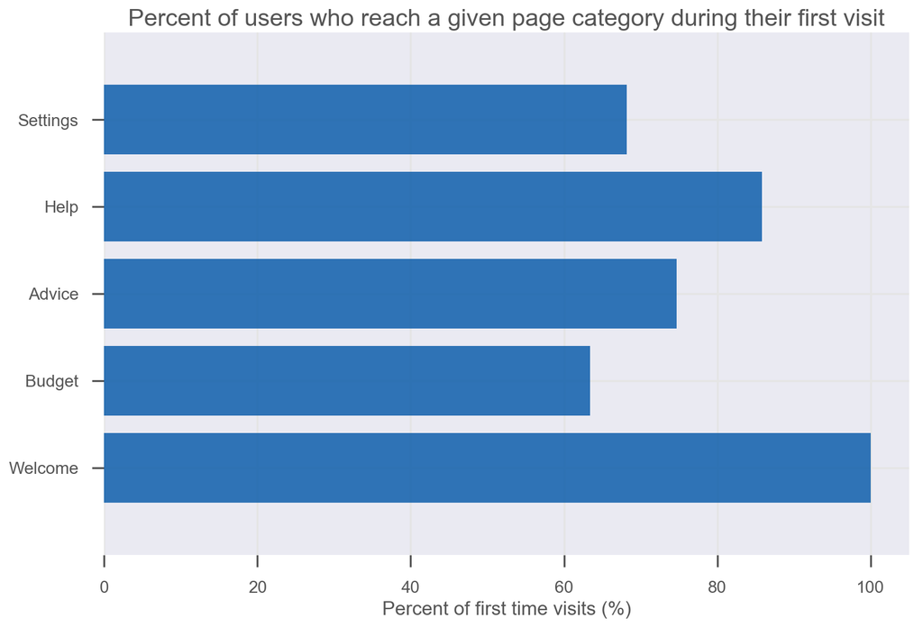

```python
percent_viewed_category = (100*(df_features[content_features] > 0).sum()/len(df_features))
bar_labels = [x.split('_')[1].capitalize() for x in content_features]
fig, ax = sv.plot(bar_labels,
                  percent_viewed_category.values, kind='barh',
                  xlabel='Percent of first time visits (%)',
                  title='Percent of users who reach a given page category during their first visit')
```

# Approach: Cluster first user visits based on behavior and content viewed

### Scale the data

Before clustering, the data is scaled to give each feature equal weight in determining the distance between observations.

```python
scaled_features = feat_plot.scaled
```

### Choosing `k`

K-means clustering requires choosing `k`, the number of clusters. To choose *k*, we can cluster using a range and comparing various performance metrics. Here, we will look at `k` between 2 and 8 and use the [silhouette score](http://scikit-learn.org/stable/modules/generated/sklearn.metrics.silhouette_score.html) and [inertia](http://scikit-learn.org/stable/modules/generated/sklearn.cluster.KMeans.html) to make our decision. We want to maximize the silhouette score and choose an inertia at the inflection point of the `k`-`inertia` graph.

```python
silhouette = []
inertia = []

for k in range(2, 9):
    model = KMeans(n_clusters=k)
    model.fit(scaled_features)
    inertia.append(model.inertia_)
    silhouette.append(metrics.silhouette_score(scaled_features, model.labels_, metric='euclidean'))
```

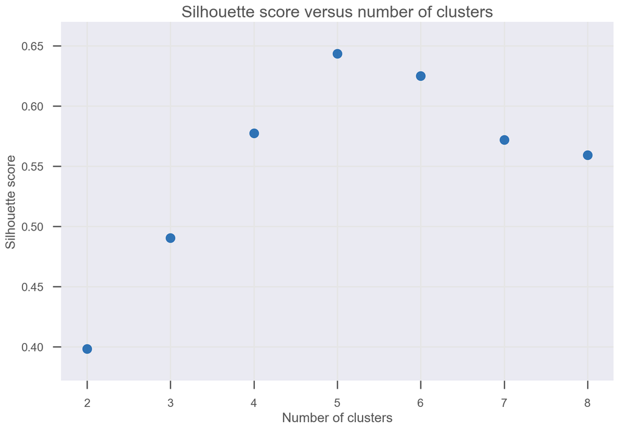

```python
sv.plot(range(2,9), silhouette[1:], kind='scatter',
       xlabel='Number of clusters',
       ylabel='Silhouette score',
       title='Silhouette score versus number of clusters');
```

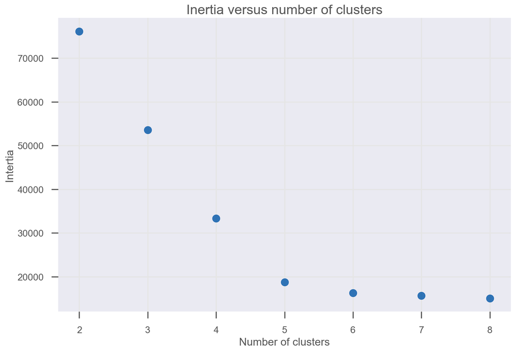

```python
sv.plot(range(2,9), inertia[1:], kind='scatter',
        xlabel='Number of clusters',
        ylabel='Intertia',
        title='Inertia versus number of clusters');
```

From the above figures, the "elbow" of the inertia figure is approximately 5. The silhouette score is at the same value of `k=5`. This value of `k` is also beneficial as categorizations are typically most meaningful and interpretable when there are less than 7 categories to analyze within business contexts.

### Checking `k` visually

```python
K = 5
```

```python
final_model = KMeans(n_clusters=K);
final_model.fit(scaled_features);
```

```python
# Create dataframe with features and final labels and make plotting object
results = df_features[content_features + behavioral_features].copy()
results['label'] = final_model.labels_

result_plot = sv.SVDSvisDF(results, column_labels=column_labels, cluster_label='label')
```

Plotting the two principal components of the features, colored by clusters, visually shows reasonable separation and no significant evidence for increasing the number further. It is obvious cluster #1 is significantly separated from the rest of the observations, which we will investigate.

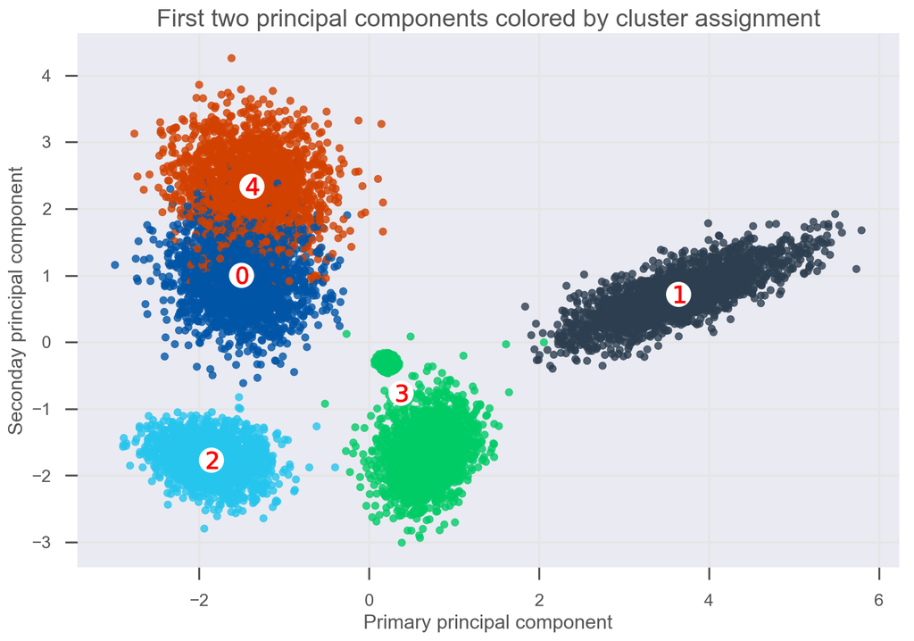

```python
fig, ax = result_plot.labeled_scatter(pca=True, size=36,
                                     xlabel='Primary principal component',
                                     ylabel='Seconday principal component',
                                     title='First two principal components colored by cluster assignment')
```

# Assessing outcomes of the resulting clusters

The clusters can be described in terms of the features used to generate them as follows:

- **Cluster 1**: Low number of pages, duration, time between pages, **explores** different pages
- **Cluster 2**: Low number of pages, duration, time between pages, focus mainly on **onboarding** pages
- **Cluster 3**: More pages, medium time between pages, **explores** different pages
- **Cluster 4**: Longer duration, longer time between pages, focused on **budgeting tool**
- **Cluster 5**: More pages, medium time between pages, mostly **advice** pages

### Return rate

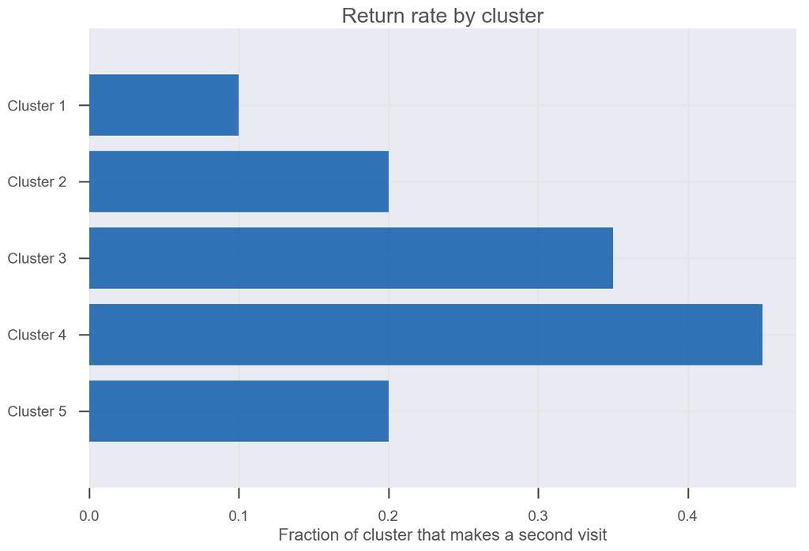

```python
fig, ax = sv.plot(['Cluster 1', 'Cluster 2', 'Cluster 3', 'Cluster 4', 'Cluster 5'][::-1],
        frac_return[::-1], kind='barh',
        xlabel='Fraction of cluster that makes a second visit',
        title='Return rate by cluster')
```

The group that spends the most time on the app and sets up their budget is the most likely to return.

### Median lifetime

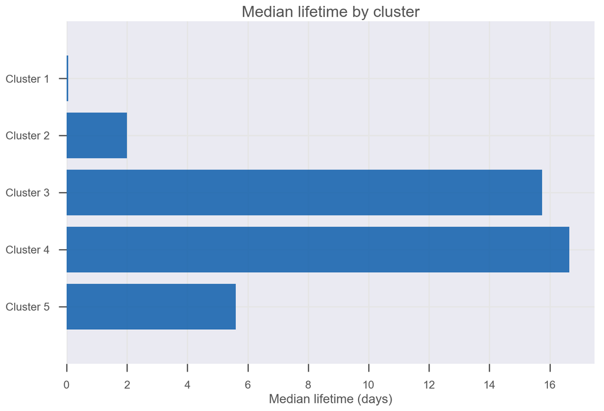

```python
fig, ax = sv.plot(['Cluster 1', 'Cluster 2', 'Cluster 3', 'Cluster 4', 'Cluster 5'][::-1],
        median_lifetime[::-1], kind='barh',
        xlabel='Median lifetime (days)',
        title='Median lifetime by cluster')
```

Those that set up a budget and those that spend a longer time exploring the app end up having the longest lifetimes.

### Median lifetime of those who return at least once

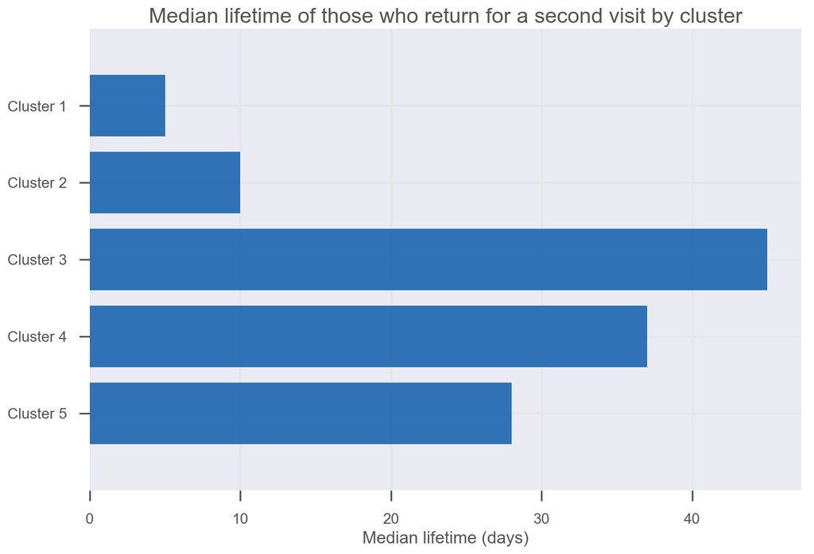

```python
fig, ax = sv.plot(['Cluster 1', 'Cluster 2', 'Cluster 3', 'Cluster 4', 'Cluster 5'][::-1],
        median_lifetime_return[::-1], kind='barh',
        xlabel='Median lifetime (days)',
        title='Median lifetime of those who return for a second visit by cluster')
```

Those who explore the app for an extended period of time during their first visit **and** make it back for a second visit show that they found value in the app and demonstrate longer lifetimes than all other segments.

# Conclusions

## Key decisions

- The number of clusters was chosen as five in order to strike a balance between the silhouette score, inertia, and utility in a business setting.

## Key Findings

1. A segment of users come in and quickly explore all of the different app features and then leave. These users are the least likely to return - they saw everything and were not interested.
2. Those who explore the app for an extended period of time during their first visit **and** make it back for a second visit show that they found value in the app and demonstrate longer lifetimes than all other segments.
3. Those who set up a budget are most likely to return a second time.

## Next steps

- Assess demographic differences between clusters.
- Dive deeper into the characteristics of users in the extended exploring cluster and assess whether specific pages or features lead to users return.

# Appendix

## Watermark

For full reproducibility of results, use exact data extraction as defined at top of notebook and ensure that the environment is exactly as follows:

```python
#  ! pip install watermark
%load_ext watermark
%watermark -v -m -p numpy,scipy,pandas,matplotlib,seaborn -g
```

```
The watermark extension is already loaded. To reload it, use:
  %reload_ext watermark
CPython 3.5.3
IPython 6.1.0

numpy 1.13.1
scipy 0.19.1
pandas 0.20.2
matplotlib 2.0.2
seaborn 0.7.1

compiler   : GCC 4.2.1 Compatible Apple LLVM 6.0 (clang-600.0.57)
system     : Darwin
release    : 15.5.0
machine    : x86_64
processor  : i386
CPU cores  : 8
interpreter: 64bit
Git hash   : f14a34d6be26ad264b403e6c2640cadf1493bbc3
```